# Bank Churn Prediction

### Background and Context

Businesses like banks that provide service have to worry about the problem of 'Churn' i.e. customers leaving and joining another service provider. It is important to understand which aspects of the service influence a customer's decision in this regard. Management can concentrate efforts on the improvement of service, keeping in mind these priorities.

### Objective

Given a Bank customer, build a neural network-based classifier that can determine whether they will leave or not in the next 6 months.

### Data Dictionary

CustomerId: Unique ID which is assigned to each customer Surname: Last name of the customer CreditScore: It defines the credit history of the customer. Geography: A customer’s location Gender: It defines the Gender of the customer Age: Age of the customer Tenure: Number of years for which the customer has been with the bank NumOfProducts: It refers to the number of products that a customer has purchased through the bank. Balance: Account balance HasCrCard: It is a categorical variable that decides whether the customer has a credit card or not. EstimatedSalary: Estimated salary isActiveMember: It is a categorical variable that decides whether the customer is an active member of the bank or not ( Active member in the sense, using bank products regularly, making transactions, etc ) Excited: It is a categorical variable that decides whether the customer left the bank within six months or not. It can take two values 0=No ( Customer did not leave the bank ) 1=Yes ( Customer left the bank )

```python
import pandas as pd
import numpy as np
from sklearn.model_selection import train_test_split
import tensorflow as tf
from sklearn import preprocessing
from tensorflow.keras.models import Sequential
import matplotlib.pyplot as plt
from tensorflow.keras import optimizers
import seaborn as sns
import keras
from keras import backend as K
from tensorflow.keras.layers import Dense, Input, Dropout,BatchNormalization
from sklearn.preprocessing import StandardScaler
from tensorflow.keras import backend
from tensorflow.keras.optimizers import Adam
from tensorflow.keras.optimizers import RMSprop
from sklearn.metrics import accuracy_score, confusion_matrix, precision_score, recall_score, f1_score, precision_recall_curve
from sklearn.metrics import classification_report
from tensorflow.keras.wrappers.scikit_learn import KerasClassifier
import random
from sklearn.model_selection import RandomizedSearchCV
```

```python
data=pd.read_csv("Churn.csv")
```

```python
data.head()
```

|  | RowNumber | CustomerId | Surname | CreditScore | Geography | Gender | Age | Tenure | Balance | NumOfProducts | HasCrCard | IsActiveMember | EstimatedSalary | Exited |
| --- | --- | --- | --- | --- | --- | --- | --- | --- | --- | --- | --- | --- | --- | --- |
| 0 | 1 | 15634602 | Hargrave | 619 | France | Female | 42 | 2 | 0.00 | 1 | 1 | 1 | 101348.88 | 1 |
| 1 | 2 | 15647311 | Hill | 608 | Spain | Female | 41 | 1 | 83807.86 | 1 | 0 | 1 | 112542.58 | 0 |
| 2 | 3 | 15619304 | Onio | 502 | France | Female | 42 | 8 | 159660.80 | 3 | 1 | 0 | 113931.57 | 1 |
| 3 | 4 | 15701354 | Boni | 699 | France | Female | 39 | 1 | 0.00 | 2 | 0 | 0 | 93826.63 | 0 |
| 4 | 5 | 15737888 | Mitchell | 850 | Spain | Female | 43 | 2 | 125510.82 | 1 | 1 | 1 | 79084.10 | 0 |

```python
print(f"there are {data.shape[0]} rows and {data.shape[1]} columns in the data")
```

```
there are 10000 rows and 14 columns in the data
```

```python
data.isnull().sum() #there is no missing value
```

```
RowNumber          0
CustomerId         0
Surname            0
CreditScore        0
Geography          0
Gender             0
Age                0
Tenure             0
Balance            0
NumOfProducts      0
HasCrCard          0
IsActiveMember     0
EstimatedSalary    0
Exited             0
dtype: int64
```

```python
data.duplicated().sum() # There is no duplicated row
```

```
0
```

```python
data.dtypes
```

```
RowNumber            int64
CustomerId           int64
Surname             object
CreditScore          int64
Geography           object
Gender              object
Age                  int64
Tenure               int64
Balance            float64
NumOfProducts        int64
HasCrCard            int64
IsActiveMember       int64
EstimatedSalary    float64
Exited               int64
dtype: object
```

```python
data.describe().T
```

|  | count | mean | std | min | 25% | 50% | 75% | max |
| --- | --- | --- | --- | --- | --- | --- | --- | --- |
| RowNumber | 10000.0 | 5.000500e+03 | 2886.895680 | 1.00 | 2500.75 | 5.000500e+03 | 7.500250e+03 | 10000.00 |
| CustomerId | 10000.0 | 1.569094e+07 | 71936.186123 | 15565701.00 | 15628528.25 | 1.569074e+07 | 1.575323e+07 | 15815690.00 |
| CreditScore | 10000.0 | 6.505288e+02 | 96.653299 | 350.00 | 584.00 | 6.520000e+02 | 7.180000e+02 | 850.00 |
| Age | 10000.0 | 3.892180e+01 | 10.487806 | 18.00 | 32.00 | 3.700000e+01 | 4.400000e+01 | 92.00 |
| Tenure | 10000.0 | 5.012800e+00 | 2.892174 | 0.00 | 3.00 | 5.000000e+00 | 7.000000e+00 | 10.00 |
| Balance | 10000.0 | 7.648589e+04 | 62397.405202 | 0.00 | 0.00 | 9.719854e+04 | 1.276442e+05 | 250898.09 |
| NumOfProducts | 10000.0 | 1.530200e+00 | 0.581654 | 1.00 | 1.00 | 1.000000e+00 | 2.000000e+00 | 4.00 |
| HasCrCard | 10000.0 | 7.055000e-01 | 0.455840 | 0.00 | 0.00 | 1.000000e+00 | 1.000000e+00 | 1.00 |
| IsActiveMember | 10000.0 | 5.151000e-01 | 0.499797 | 0.00 | 0.00 | 1.000000e+00 | 1.000000e+00 | 1.00 |
| EstimatedSalary | 10000.0 | 1.000902e+05 | 57510.492818 | 11.58 | 51002.11 | 1.001939e+05 | 1.493882e+05 | 199992.48 |
| Exited | 10000.0 | 2.037000e-01 | 0.402769 | 0.00 | 0.00 | 0.000000e+00 | 0.000000e+00 | 1.00 |

```python
data.nunique()
```

```
RowNumber          10000
CustomerId         10000
Surname             2932
CreditScore          460
Geography              3
Gender                 2
Age                   70
Tenure                11
Balance             6382
NumOfProducts          4
HasCrCard              2
IsActiveMember         2
EstimatedSalary     9999
Exited                 2
dtype: int64
```

```python
data.info() # recheck the data
```

```
<class 'pandas.core.frame.DataFrame'>
RangeIndex: 10000 entries, 0 to 9999
Data columns (total 14 columns):
 #   Column           Non-Null Count  Dtype
---  ------           --------------  -----
 0   RowNumber        10000 non-null  int64
 1   CustomerId       10000 non-null  int64
 2   Surname          10000 non-null  object
 3   CreditScore      10000 non-null  int64
 4   Geography        10000 non-null  object
 5   Gender           10000 non-null  object
 6   Age              10000 non-null  int64
 7   Tenure           10000 non-null  int64
 8   Balance          10000 non-null  float64
 9   NumOfProducts    10000 non-null  int64
 10  HasCrCard        10000 non-null  int64
 11  IsActiveMember   10000 non-null  int64
 12  EstimatedSalary  10000 non-null  float64
 13  Exited           10000 non-null  int64
dtypes: float64(2), int64(9), object(3)
memory usage: 1.1+ MB
```

```python
df = data.copy()
```

```python
df.head()
```

|  | RowNumber | CustomerId | Surname | CreditScore | Geography | Gender | Age | Tenure | Balance | NumOfProducts | HasCrCard | IsActiveMember | EstimatedSalary | Exited |
| --- | --- | --- | --- | --- | --- | --- | --- | --- | --- | --- | --- | --- | --- | --- |
| 0 | 1 | 15634602 | Hargrave | 619 | France | Female | 42 | 2 | 0.00 | 1 | 1 | 1 | 101348.88 | 1 |
| 1 | 2 | 15647311 | Hill | 608 | Spain | Female | 41 | 1 | 83807.86 | 1 | 0 | 1 | 112542.58 | 0 |
| 2 | 3 | 15619304 | Onio | 502 | France | Female | 42 | 8 | 159660.80 | 3 | 1 | 0 | 113931.57 | 1 |
| 3 | 4 | 15701354 | Boni | 699 | France | Female | 39 | 1 | 0.00 | 2 | 0 | 0 | 93826.63 | 0 |
| 4 | 5 | 15737888 | Mitchell | 850 | Spain | Female | 43 | 2 | 125510.82 | 1 | 1 | 1 | 79084.10 | 0 |

```python
df.drop(["RowNumber","CustomerId","Surname"], axis=1, inplace=True)
```

```python
cat_list=["Exited","IsActiveMember","HasCrCard","Geography","Gender","NumOfProducts"]
cat_list
```

```
['Exited',
 'IsActiveMember',
 'HasCrCard',
 'Geography',
 'Gender',
 'NumOfProducts']
```

```python
for i in cat_list:
    df[i] = df[i].astype("category")
```

```python
df.dtypes
```

```
CreditScore           int64
Geography          category
Gender             category
Age                   int64
Tenure                int64
Balance             float64
NumOfProducts      category
HasCrCard          category
IsActiveMember     category
EstimatedSalary     float64
Exited             category
dtype: object
```

```python
num_list=["CreditScore","Age","Tenure","Balance","EstimatedSalary"]
```

###### Reading Dataset and Feature Elimination

1) There are 10000 rows and 14 columns in the data. 2) There is no missing value in the data. 3) There is no duplicated row. 4) Exited, IsActiveMember, HasCrCard, Geography, and Gender should be categorical. 5)RowNumber, CustomerId, and Surname should be dropped because these variables do not help the model and unique for each customer. 6)The ages of the customers ranged from 18 to 92 and the mean of Age variable is 38.92 7) The mean credit score is 650.52

### Univariate Analysis

```python
def labeled_barplot(data, feature, percentage=False, n=None):
    total = len(data[feature])
    count = data[feature].nunique()
    if n is None:
        plt.figure(figsize=(count + 1, 6))
    else:
        plt.figure(figsize=(n + 1, 6))

    plt.xticks(rotation=45, fontsize=10)
    ax = sns.countplot(
        data=data,
        x=feature,
        palette="Set2",
        order=data[feature].value_counts().index[:n].sort_values(),
    )

    for p in ax.patches:
        if percentage == True:
            label = "{:.1f}%".format(
                100 * p.get_height() / total
            )
        else:
            label = p.get_height()

        x = p.get_x() + p.get_width() / 2
        y = p.get_height()

        ax.annotate(
            label,
            (x, y),
            ha="center",
            va="center",
            size=12,
            xytext=(0, 5),
            textcoords="offset points",
        )

    plt.show()
```

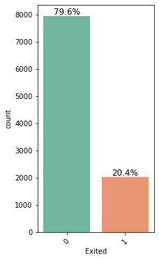

```
None
################################################################################
```

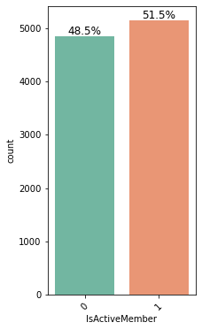

```
None
################################################################################
```

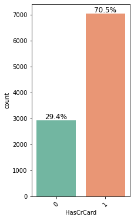

```
None
################################################################################
```

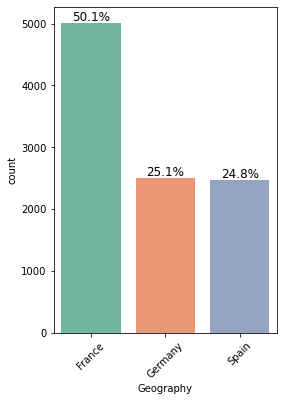

```
None
################################################################################
```

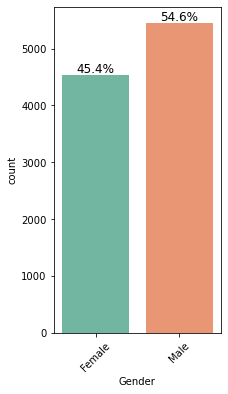

```
None
################################################################################
```

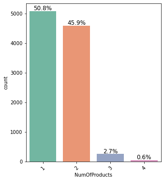

```
None
################################################################################
```

```python
for feature in cat_list:
    print(labeled_barplot(df, feature, percentage=True))
    print("#"*80)
```

##### Observation

1) 20.4% of the customers left the bank. Exit is the imbalanced target variable because the frequency of the customers who did not leave the bank value is higher than the frequency of customers who left the bank. 2) 70.5% of the customers have cards, 3) The customers' locations are France, Germany, and Spain. Almost half of the customers' locations is France. 4)The number of male customers is more than the number of female customers. 5) Most of the customers have one or two products. 0.6% of the customers have four products.

```python
def boxplot_hitogram(data, feature, figsize=(10, 5), kde=True, bins=20):

    f2, (ax_box2, ax_hist2) = plt.subplots(
        nrows=2,
        sharex=True,
        gridspec_kw={"height_ratios": (0.25, 0.75)},
        figsize=figsize,
    )
    sns.boxplot(
        data=data, x=feature, ax=ax_box2, showmeans=True, color="yellowgreen"
    )
    sns.histplot(
        data=data, x=feature, kde=kde, ax=ax_hist2, bins=bins, palette="pink"
    ) if bins else sns.histplot(
        data=data, x=feature, kde=kde, ax=ax_hist2
    )
    ax_hist2.axvline(
        data[feature].mean(), color="lime", linestyle="-"
    )
    ax_hist2.axvline(
        data[feature].median(), color="red", linestyle="--"
    )
```

```
None
None
None
None
None
```

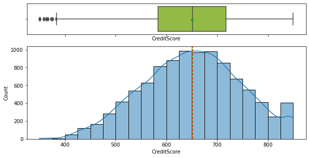

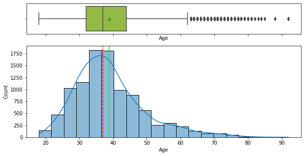

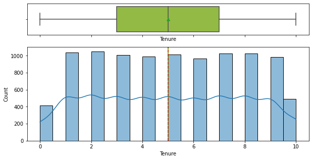

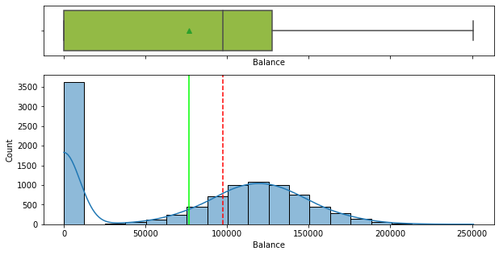

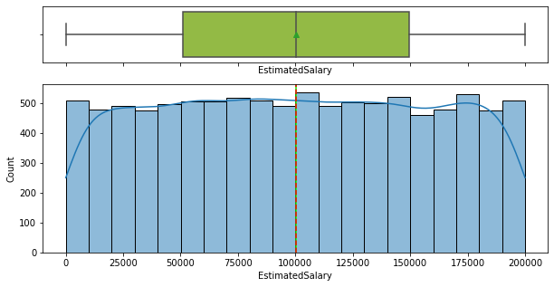

```python
for feature in num_list:
    print(boxplot_hitogram(df, feature))
```

##### Observation

1) The CreditScore variable is left-skewed and has outliers. 2) The Age variable is right-skewed and has outliers. 3) The Tenure feature ranged from 0 to 10 and has the same mean and median score( mean=median=5) 4) A significant number of customers have 0 balance. 5) The EstimatedSalary variable does not have outliers.

### Bivariate Analysis

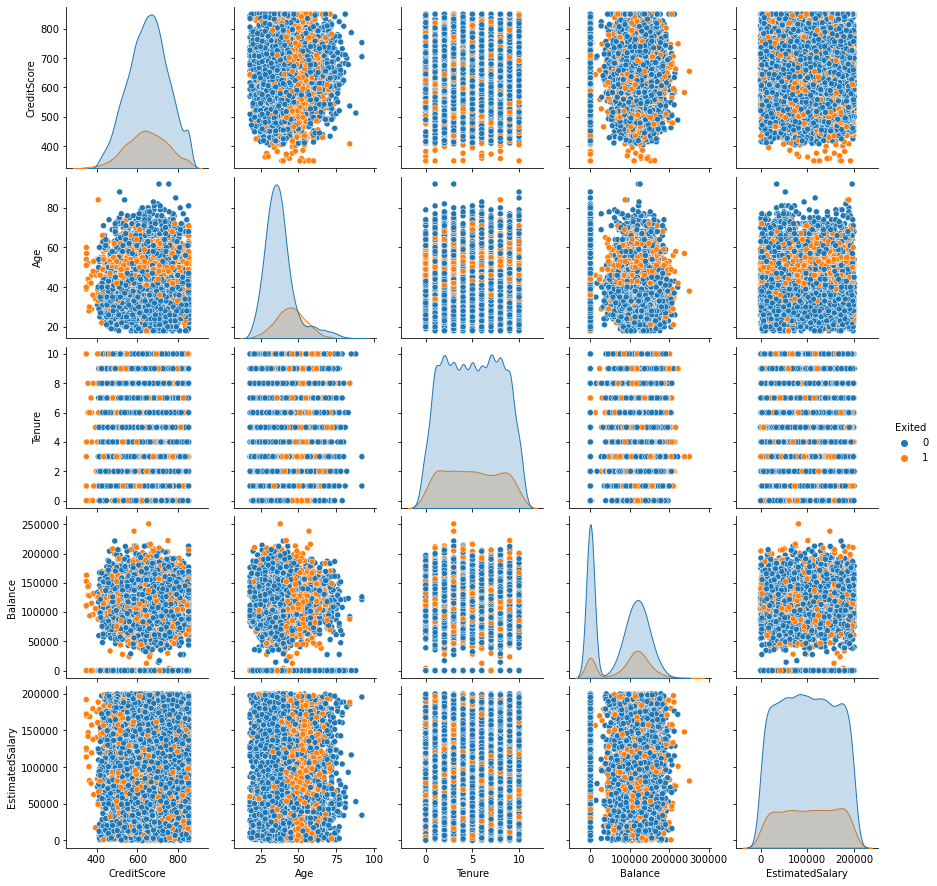

```python
sns.pairplot(df, hue="Exited")
```

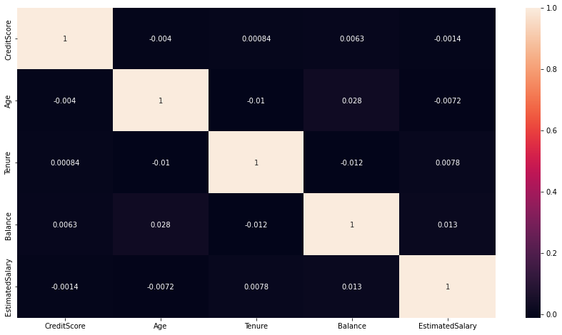

```python
plt.figure(figsize=(15,8)) # There is no high correlation between variables
sns.heatmap(df.corr(), annot=True)
```

```python
def stc_barplot(data, predictor, target):
    count = data[predictor].nunique()
    sorter = data[target].value_counts().index[-1]
    tab1 = pd.crosstab(data[predictor], data[target], margins=True).sort_values(
        by=sorter, ascending=False
    )
    print(tab1)
    print("*" * 100)
    tab = pd.crosstab(data[predictor], data[target], normalize="index").sort_values(
        by=sorter, ascending=False
    )
    tab.plot(kind="bar", stacked=True, figsize=(count + 1, 5))
    plt.legend(
        loc="lower left",
        frameon=False,
    )
    plt.legend(loc="upper left", bbox_to_anchor=(1, 1))
    plt.show()
```

```
Exited             0     1    All
IsActiveMember
All             7963  2037  10000
0               3547  1302   4849
1               4416   735   5151
```

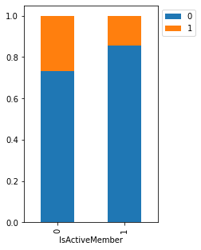

```python
stc_barplot(data, "IsActiveMember", "Exited")
```

```
Exited        0     1    All
HasCrCard
All        7963  2037  10000
1          5631  1424   7055
0          2332   613   2945
```

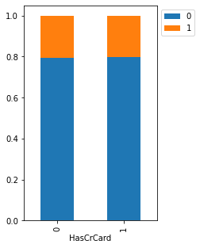

```python
stc_barplot(data, "HasCrCard", "Exited")
```

```
Exited        0     1    All
Geography
All        7963  2037  10000
Germany    1695   814   2509
France     4204   810   5014
Spain      2064   413   2477
```

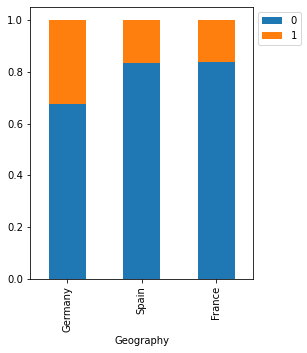

```python
stc_barplot(data, "Geography", "Exited")
```

```
Exited     0     1    All
Gender
All     7963  2037  10000
Female  3404  1139   4543
Male    4559   898   5457
```

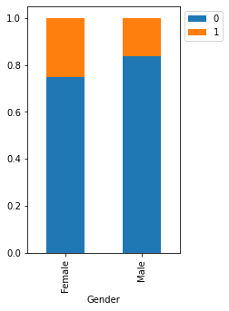

```python
stc_barplot(data, "Gender", "Exited")
```

##### Observation

1) Customers who are not active members are more likely to leave the bank. 2) Having a credit card is more likely not to influence the customers' decision about leaving or not leaving the bank. 3) Customers in Germany are more likely to leave the bank. 4) Female customers are more likely to leave the bank. 5) There is no high correlation between variables.

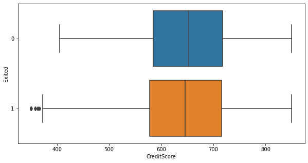

```python
plt.figure(figsize=(10,5))
sns.boxplot(x="CreditScore", y="Exited", data=df, orient="h")
```

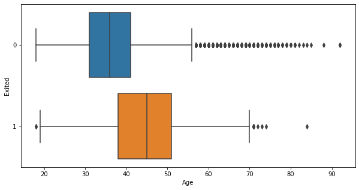

```python
plt.figure(figsize=(10,5))
sns.boxplot(x="Age", y="Exited", data=df, orient="h")
```

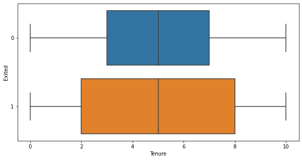

```python
plt.figure(figsize=(10,5))
sns.boxplot(x="Tenure", y="Exited", data=df, orient="h")
```

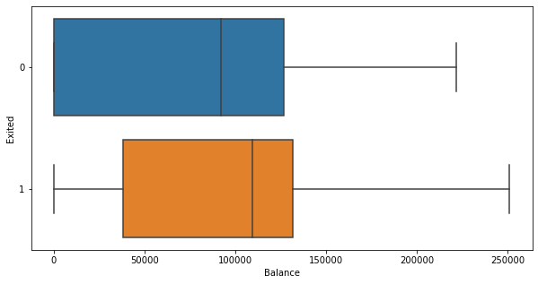

```python
plt.figure(figsize=(10,5))
sns.boxplot(x="Balance", y="Exited", data=df, orient="h")
```

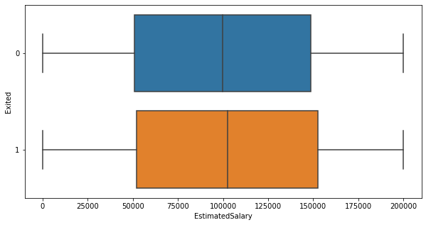

```python
plt.figure(figsize=(10,5))
sns.boxplot(x="EstimatedSalary", y="Exited", data=df, orient="h")
```

### Data Preparation for Modeling

```python
df.drop(["HasCrCard"], axis=1, inplace=True) # Drop the HasCrCard variable because it most likely does not influence the customers' decision about exiting the bank.
```

```python
X= df.drop(["Exited"], axis=1)
y=df["Exited"]
```

```python
print(X.shape)
print(y.shape)
```

```
(10000, 9)
(10000,)
```

Splitting the Data into train and test set

```python
X_train, X_test, y_train, y_test = train_test_split(X, y, test_size = 0.2, random_state = 1)
```

```python
X_train.head()
```

|  | CreditScore | Geography | Gender | Age | Tenure | Balance | NumOfProducts | IsActiveMember | EstimatedSalary |
| --- | --- | --- | --- | --- | --- | --- | --- | --- | --- |
| 2694 | 628 | Germany | Male | 29 | 3 | 113146.98 | 2 | 1 | 124749.08 |
| 5140 | 626 | France | Female | 29 | 4 | 105767.28 | 2 | 0 | 41104.82 |
| 2568 | 612 | Germany | Female | 47 | 6 | 130024.87 | 1 | 1 | 45750.21 |
| 3671 | 646 | Germany | Female | 52 | 6 | 111739.40 | 2 | 1 | 68367.18 |
| 7427 | 714 | Spain | Male | 33 | 8 | 122017.19 | 1 | 0 | 162515.17 |

Scaling the data

```python
sc=StandardScaler()
temp = sc.fit(X_train[["CreditScore","Age","Tenure","Balance","EstimatedSalary"]])
X_train[["CreditScore","Age","Tenure","Balance","EstimatedSalary"]] = temp.transform(X_train[["CreditScore","Age","Tenure","Balance","EstimatedSalary"]])
X_test[["CreditScore","Age","Tenure","Balance","EstimatedSalary"]] = temp.transform(X_test[["CreditScore","Age","Tenure","Balance","EstimatedSalary"]])
```

```python
X_train.head()
```

|  | CreditScore | Geography | Gender | Age | Tenure | Balance | NumOfProducts | IsActiveMember | EstimatedSalary |
| --- | --- | --- | --- | --- | --- | --- | --- | --- | --- |
| 2694 | -0.230820 | Germany | Male | -0.944500 | -0.701742 | 0.588173 | 2 | 1 | 0.427394 |
| 5140 | -0.251509 | France | Female | -0.944500 | -0.355203 | 0.469849 | 2 | 0 | -1.025487 |
| 2568 | -0.396330 | Germany | Female | 0.774987 | 0.337876 | 0.858788 | 1 | 1 | -0.944798 |
| 3671 | -0.044622 | Germany | Female | 1.252622 | 0.337876 | 0.565604 | 2 | 1 | -0.551946 |
| 7427 | 0.658795 | Spain | Male | -0.562392 | 1.030954 | 0.730395 | 1 | 0 | 1.083383 |

```python
X_train = pd.get_dummies(X_train,columns= ["Geography","Gender","NumOfProducts","IsActiveMember"],drop_first =True)
X_test = pd.get_dummies(X_test,columns= ["Geography","Gender","NumOfProducts","IsActiveMember"],drop_first =True)
```

```python
X_train.head()
```

|  | CreditScore | Age | Tenure | Balance | EstimatedSalary | Geography_Germany | Geography_Spain | Gender_Male | NumOfProducts_2 | NumOfProducts_3 | NumOfProducts_4 | IsActiveMember_1 |
| --- | --- | --- | --- | --- | --- | --- | --- | --- | --- | --- | --- | --- |
| 2694 | -0.230820 | -0.944500 | -0.701742 | 0.588173 | 0.427394 | 1 | 0 | 1 | 1 | 0 | 0 | 1 |
| 5140 | -0.251509 | -0.944500 | -0.355203 | 0.469849 | -1.025487 | 0 | 0 | 0 | 1 | 0 | 0 | 0 |
| 2568 | -0.396330 | 0.774987 | 0.337876 | 0.858788 | -0.944798 | 1 | 0 | 0 | 0 | 0 | 0 | 1 |
| 3671 | -0.044622 | 1.252622 | 0.337876 | 0.565604 | -0.551946 | 1 | 0 | 0 | 1 | 0 | 0 | 1 |
| 7427 | 0.658795 | -0.562392 | 1.030954 | 0.730395 | 1.083383 | 0 | 1 | 1 | 0 | 0 | 0 | 0 |

##### Model evaluation criterion

There are two wrong predictions: 1) Predicting a customer exits but the customer does not exit. This is false positive, precision. 2) Predicting a customer does not exit, but the customer exits, False negative, Recall. In this case, if the model has a high false negative, the bank would have a heavy loss, so the bank would want to detect exited customers, reduce the false negative, and have a high recall score.

# Model Building

##### Model0

An NN model with one hidden layer with ReLu activation will be developed. The NN takes a vector of length 12 input. The final layer will output a probability distribution (sigmoid activation function) and classify either as not exited or exited the bank.

```python
backend.clear_session()
np.random.seed(42)
import random
random.seed(42)
tf.random.set_seed(42)
```

```python
model0 = Sequential()
model0.add(Dense(128, activation = 'relu',kernel_initializer='he_uniform', input_dim = 12))
model0.add(Dense(1, activation = 'sigmoid'))
```

```python
model0.compile(optimizer=Adam(learning_rate=0.0001), loss='binary_crossentropy', metrics=['accuracy'])
```

```python
history0=model0.fit(X_train, y_train,
          validation_split=0.2,
          epochs=20,
          batch_size=32,verbose=1)
```

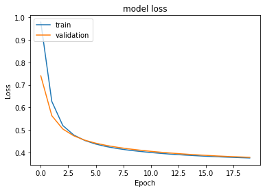

```python
plt.plot(history0.history['loss'])
plt.plot(history0.history['val_loss'])
plt.title('model loss')
plt.ylabel('Loss')
plt.xlabel('Epoch')
plt.legend(['train', 'validation'], loc='upper left')
plt.show()
```

```python
result = model0.evaluate(X_test, y_test)
```

```python
y_pred0=model0.predict(X_test)
```

```python
y_pred0 = (y_pred0 > 0.5)
y_pred0
```

```
array([[False],
       [False],
       [False],
       ...,
       [False],
       [False],
       [False]])
```

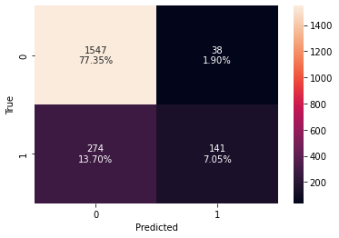

```python
cm = confusion_matrix(y_test, y_pred0)
labels = np.asarray(
        [
            ["{0:0.0f}".format(item) + "\n{0:.2%}".format(item / cm.flatten().sum())]
            for item in cm.flatten()
        ]
    ).reshape(2, 2)

plt.figure(figsize=(6, 4))
sns.heatmap(cm, annot=labels, fmt="")
plt.ylabel("True")
plt.xlabel("Predicted")
```

```python
print(classification_report(y_test,y_pred0))
```

```
              precision    recall  f1-score   support

           0       0.85      0.98      0.91      1585
           1       0.79      0.34      0.47       415

    accuracy                           0.84      2000
   macro avg       0.82      0.66      0.69      2000
weighted avg       0.84      0.84      0.82      2000
```

Let's tune the threshold using ROC-AUC for model0

```
Best Threshold=0.214080, G-Mean=0.776
```

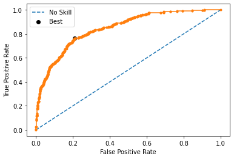

```python
from sklearn.metrics import roc_curve
from matplotlib import pyplot
yhat0 = model0.predict(X_test)
yhat0 = yhat0[:, 0]
fpr, tpr, thresholds0 = roc_curve(y_test, yhat0)
gmeans0 = np.sqrt(tpr * (1-fpr))
ix = np.argmax(gmeans0)
print('Best Threshold=%f, G-Mean=%.3f' % (thresholds0[ix], gmeans0[ix]))
pyplot.plot([0,1], [0,1], linestyle='--', label='No Skill')
pyplot.plot(fpr, tpr, marker='.')
pyplot.scatter(fpr[ix], tpr[ix], marker='o', color='black', label='Best')
pyplot.xlabel('False Positive Rate')
pyplot.ylabel('True Positive Rate')
pyplot.legend()
pyplot.show()
```

```python
y_pred_th0=model0.predict(X_test)
y_pred_th0 = (y_pred_th0 > thresholds0[ix])
y_pred_th0
```

```
array([[False],
       [False],
       [False],
       ...,
       [False],
       [False],
       [ True]])
```

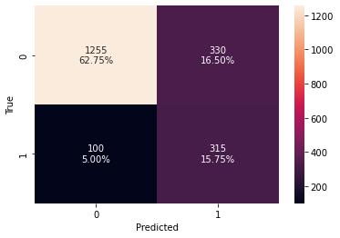

```python
cm = confusion_matrix(y_test, y_pred_th0)
labels = np.asarray(
        [
            ["{0:0.0f}".format(item) + "\n{0:.2%}".format(item / cm.flatten().sum())]
            for item in cm.flatten()
        ]
    ).reshape(2, 2)

plt.figure(figsize=(6, 4))
sns.heatmap(cm, annot=labels, fmt="")
plt.ylabel("True")
plt.xlabel("Predicted")
```

```python
print(classification_report(y_test,y_pred_th0))
```

```
              precision    recall  f1-score   support

           0       0.93      0.79      0.85      1585
           1       0.49      0.76      0.59       415

    accuracy                           0.79      2000
   macro avg       0.71      0.78      0.72      2000
weighted avg       0.84      0.79      0.80      2000
```

Model0 is not overfitting. Model 0 with the best threshold(0.214) has a 0.76 recall score.

##### Model1

A model with three hidden layers fully-connected with ReLu activation will be developed. The NN takes a vector of length 12 input. The final layer will output a probability distribution (sigmoid activation function) and classify either as not exited or exited.

```python
backend.clear_session()
np.random.seed(42)
import random
random.seed(42)
tf.random.set_seed(42)
```

```python
model1 = Sequential()
model1.add(Dense(64, activation = 'relu',kernel_initializer='he_uniform', input_dim = 12))
model1.add(Dense(32, activation='relu',kernel_initializer='he_uniform'))
model1.add(Dense(32, activation='relu',kernel_initializer='he_uniform'))
model1.add(Dense(1, activation = 'sigmoid'))
```

```python
model1.compile(optimizer=Adam(learning_rate=0.001), loss='binary_crossentropy', metrics=['accuracy'])
```

```python
history1=model1.fit(X_train, y_train,
          validation_split=0.2,
          epochs=50,
          batch_size=32,verbose=1)
```

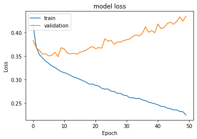

```python
plt.plot(history1.history['loss'])
plt.plot(history1.history['val_loss'])
plt.title('model loss')
plt.ylabel('Loss')
plt.xlabel('Epoch')
plt.legend(['train', 'validation'], loc='upper left')
plt.show()
```

The model is overfitting based on the train and validation loss.

```python
result = model1.evaluate(X_test, y_test)
```

The model has an 0.85 % accuracy, but it is overfitting.

```python
y_pred1=model1.predict(X_test)
```

```python
y_pred1 = (y_pred1 > 0.5)
y_pred1
```

```
array([[False],
       [False],
       [False],
       ...,
       [False],
       [False],
       [ True]])
```

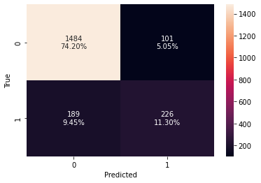

```python
cm = confusion_matrix(y_test, y_pred1)
labels = np.asarray(
        [
            ["{0:0.0f}".format(item) + "\n{0:.2%}".format(item / cm.flatten().sum())]
            for item in cm.flatten()
        ]
    ).reshape(2, 2)

plt.figure(figsize=(6, 4))
sns.heatmap(cm, annot=labels, fmt="")
plt.ylabel("True")
plt.xlabel("Predicted")
```

```python
from sklearn.metrics import classification_report
print(classification_report(y_test,y_pred1))
```

```
              precision    recall  f1-score   support

           0       0.89      0.94      0.91      1585
           1       0.69      0.54      0.61       415

    accuracy                           0.85      2000
   macro avg       0.79      0.74      0.76      2000
weighted avg       0.85      0.85      0.85      2000
```

Let's use RMSprop as an optimizer

```python
model1.compile(optimizer=RMSprop(learning_rate=0.001), loss='binary_crossentropy', metrics=['accuracy'])
```

```python
history1_RMSprop=model1.fit(X_train, y_train,
          validation_split=0.2,
          epochs=50,
          batch_size=32,verbose=1)
```

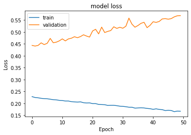

```python
plt.plot(history1_RMSprop.history['loss'])
plt.plot(history1_RMSprop.history['val_loss'])
plt.title('model loss')
plt.ylabel('Loss')
plt.xlabel('Epoch')
plt.legend(['train', 'validation'], loc='upper left')
plt.show()
```

Model1 with RMSprop optimizer is also overfitting.

Let's tune the threshold using ROC-AUC for model1

```
Best Threshold=0.158268, G-Mean=0.731
```

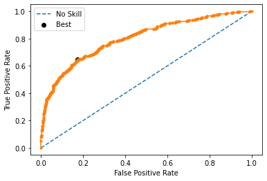

```python
from sklearn.metrics import roc_curve
from matplotlib import pyplot
yhat1 = model1.predict(X_test)
yhat1 = yhat1[:, 0]
fpr, tpr, thresholds1 = roc_curve(y_test, yhat1)
gmeans1 = np.sqrt(tpr * (1-fpr))
ix = np.argmax(gmeans1)
print('Best Threshold=%f, G-Mean=%.3f' % (thresholds1[ix], gmeans1[ix]))
pyplot.plot([0,1], [0,1], linestyle='--', label='No Skill')
pyplot.plot(fpr, tpr, marker='.')
pyplot.scatter(fpr[ix], tpr[ix], marker='o', color='black', label='Best')
pyplot.xlabel('False Positive Rate')
pyplot.ylabel('True Positive Rate')
pyplot.legend()
pyplot.show()
```

```python
y_pred_th1=model1.predict(X_test)
y_pred_th1 = (y_pred_th1 > thresholds1[ix])
y_pred_th1
```

```
array([[False],
       [ True],
       [False],
       ...,
       [False],
       [False],
       [ True]])
```

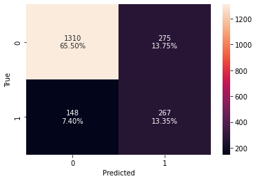

```python
cm = confusion_matrix(y_test, y_pred_th1)
labels = np.asarray(
        [
            ["{0:0.0f}".format(item) + "\n{0:.2%}".format(item / cm.flatten().sum())]
            for item in cm.flatten()
        ]
    ).reshape(2, 2)

plt.figure(figsize=(6, 4))
sns.heatmap(cm, annot=labels, fmt="")
plt.ylabel("True")
plt.xlabel("Predicted")
```

```python
print(classification_report(y_test,y_pred_th1))
```

```
              precision    recall  f1-score   support

           0       0.90      0.83      0.86      1585
           1       0.49      0.64      0.56       415

    accuracy                           0.79      2000
   macro avg       0.70      0.73      0.71      2000
weighted avg       0.81      0.79      0.80      2000
```

Recall score is 0.64 and the accuracy is low.